# Project Python Foundations: FoodHub Data Analysis

### **Question 7**: Which are the top 5 restaurants in terms of the number of orders received? [1 mark]

```python
# Group by 'restaurant_name' and count the number of occurrences
restaurant_counts = df['restaurant_name'].value_counts()

# Sort the restaurant counts in descending order and select the top 5
top_restaurants = restaurant_counts.head(5)
```

```python
# Print the top 5 restaurants and their corresponding order counts
print("Top 5 restaurants in terms of number of orders:")
for restaurant, count in top_restaurants.items():
    print(f"{restaurant}: {count} orders")
```

```
Top 5 restaurants in terms of number of orders:
Shake Shack: 219 orders
The Meatball Shop: 132 orders
Blue Ribbon Sushi: 119 orders
Blue Ribbon Fried Chicken: 96 orders
Parm: 68 orders
```

#### Observations:

- Names of the first five restaurants, with respect to the number of the orders they received, are Shake Shack (219 orders), The Meatball Shop (132 orders), Blue Ribbon Sushi (119 orders), Blue Ribbon Fried Chicken (96 orders) and Parm (68 orders)
- The top restaurant's order number is 219 followed by 132, 119, 96 and 6 which are not very high when we compare with total number of the orders that is 1898 . This information reveal that customers ordered from large range of the restaurants.

### **Question 8**: Which is the most popular cuisine on weekends? [1 mark]

```python
# Find most popular cuisine on weekends
df[df['day_of_the_week']=='Weekend']['cuisine_type'].value_counts().head(3)
```

```
American    415
Japanese    335
Italian     207
Name: cuisine_type, dtype: int64
```

#### Observations:

Most popular cuisine on weekends is 'American' cuisine, followed by Japanese and Italian cuisines.

### **Question 9**: What percentage of the orders cost more than 20 dollars? [2 marks]

```python
# Calculate the total number of orders
total_orders = len(df)

# Calculate the number of orders that cost more than 20 dollars
orders_above_20 = len(df[df['cost_of_the_order'] > 20])

# Calculate the percentage of orders that cost more than 20 dollars
percentage_above_20 = (orders_above_20 / total_orders) * 100

# Print the percentage of orders that cost more than 20 dollars
print("The percentage of orders that cost more than $20 is", round(percentage_above_20,2), "%.")
```

```
The percentage of orders that cost more than $20 is 29.24 %.
```

#### Observations:

Only about 30% of the orders cost more than 20 dollars. That means majority of the orders, about 70% , cost less than 20 dollars.

### **Question 10**: What is the mean order delivery time? [1 mark]

```python
# Calculate the mean order delivery time
mean_delivery_time = df['delivery_time'].mean()

print('The mean order delivery time is', round(mean_delivery_time, 2), 'minutes.')
```

```
The mean order delivery time is 24.16 minutes.
```

#### Observations:

The average delivery time for orders is about 24 min.

### **Question 11:** The company has decided to give 20% discount vouchers to the top 3 most frequent customers. Find the IDs of these customers and the number of orders they placed. [1 mark]

```python
# Group the dataframe by 'customer_id' and count the number of orders for each customer
customer_order_counts = df['customer_id'].value_counts()

# Select the top 3 customers with the highest order counts
top_customers = customer_order_counts.head(3)

# Print the IDs of the top 3 customers and their corresponding order counts
print("Top 3 most frequent customers:")
for customer_id, order_count in top_customers.items():
    print("Customer ID:", customer_id,"," ,"Order Count:", order_count)
```

```
Top 3 most frequent customers:
Customer ID: 52832 , Order Count: 13
Customer ID: 47440 , Order Count: 10
Customer ID: 83287 , Order Count: 9
```

#### Observations:

- Order counts for customers who earned 20% discount voucher are 13,10 and 9 in order. These numbers are not very high when we compare with the total number of the orders given. We need more information about in which time interval the data was collected.
- The frequency of using the app by customers can be increased by other promotions. For example; giving voucher to customers who has highest 5 (or 10) order number or whose total cost of orders is higher than 50 dollars.

### **Question 12**: Perform a multivariate analysis to explore relationships between the important variables in the dataset. (It is a good idea to explore relations between numerical variables as well as relations between numerical and categorical variables) [10 marks]

**Relationship between Cuisine Type and Cost of the Order**

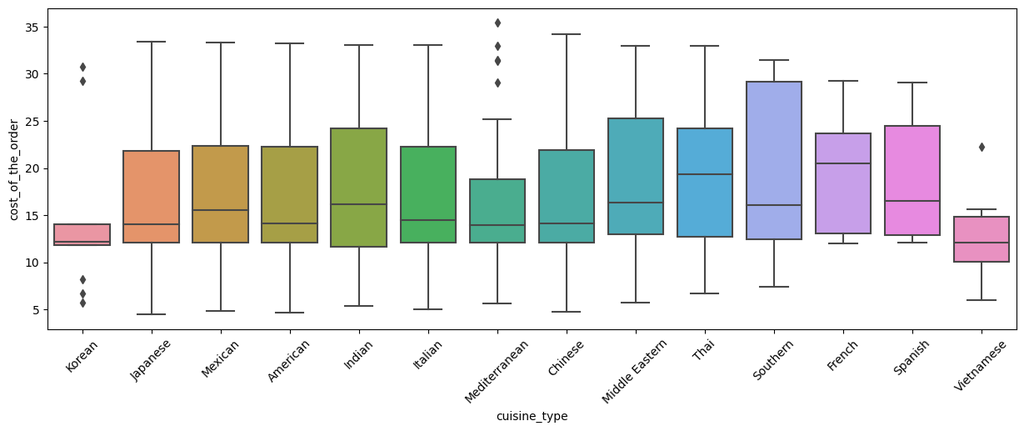

```python
plt.figure(figsize=(15,5))
sns.boxplot(data=df, x = "cuisine_type", y = "cost_of_the_order")
plt.xticks(rotation = 45)
plt.show()
```

Observations:

- French cuisine has the highest median cost ( 20 dollars) for the orders. The cost range for Southern cuisine is larger than others.
- The cost range for Southern cuisine is larger than others.
- Although median cost for Mediterranean cuisine is not high, there are some foods that has the highest cost.

**Relationship between Cuisine Type and Food Preparation Time**

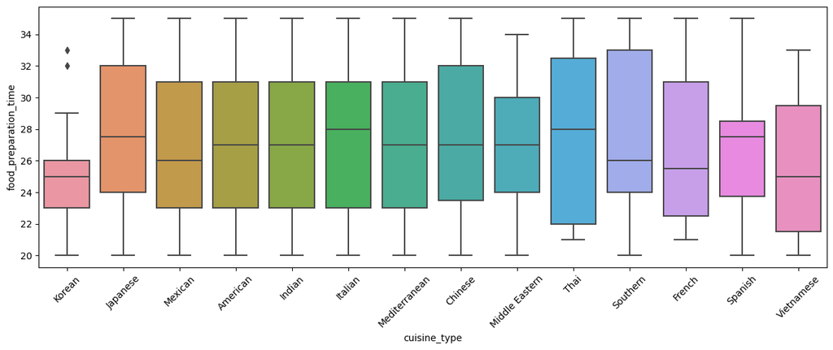

```python
plt.figure(figsize=(15,5))
sns.boxplot(data=df, x = "cuisine_type", y = "food_preparation_time")
plt.xticks(rotation = 45)
plt.show()
```

Observations:

- Although for some cuisines such as Thai, median food preparation time is slightly higher, median food preparation time for cuisines are close to each other. That suggests type of the cuisine do not play a crucial role on the time taken to prepare the food ordered.

**Relation between Day of the Week and Delivery Time**

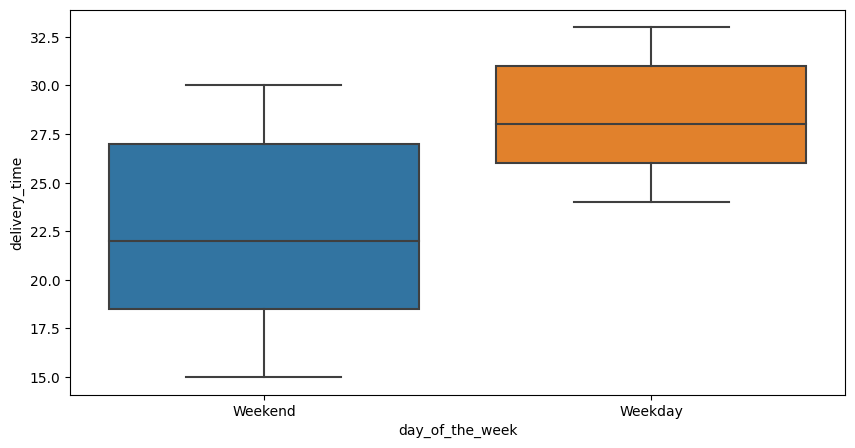

```python
plt.figure(figsize=(10,5))
sns.boxplot(data=df, x = "day_of_the_week", y = "delivery_time")
plt.show()
```

Observations:

- Median delivery time on weekdays (28 min) is higher than median delivery time on weekend (22 min). On weekend, ordered food is delivered faster than the weekdays.

**Relation between Rating and Delivery Time**

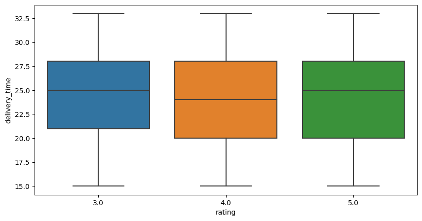

```python
plt.figure(figsize=(10, 5))
sns.boxplot(data=df, x = 'rating', y = 'delivery_time')
plt.show()
```

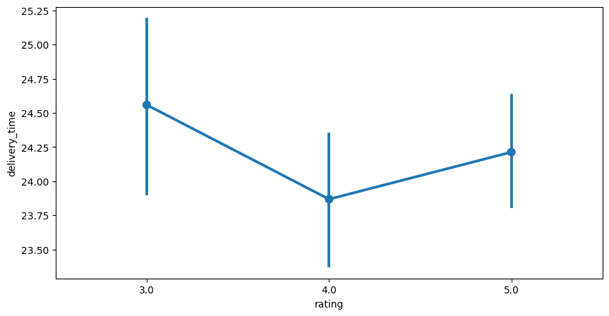

```python
plt.figure(figsize=(10, 5))
sns.pointplot(data=df, x = 'rating', y = 'delivery_time')
plt.show()
```

Observations:

- Median delivery time for orders received rating 4 is slightly lower than the median delivery time for orders who received 3 and 5.
- Orders who received rating 3 had highest median delivery time.
- However the difference is not so significant and we can conlude that there is no significant relationship seen between delivery time and ratings.

**Relationship between Rating and Food Preparation Time**

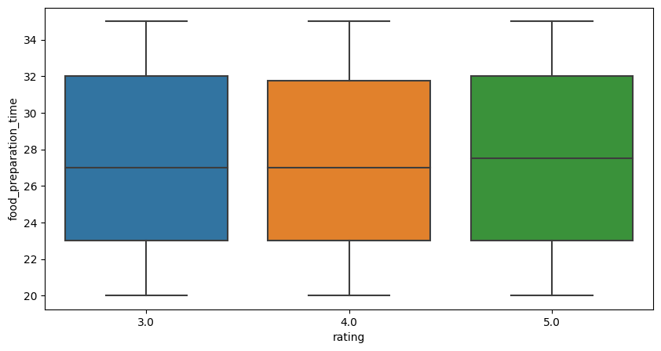

```python
plt.figure(figsize=(10, 5))
sns.boxplot(data=df, x = 'rating', y = 'food_preparation_time')
plt.show()
```

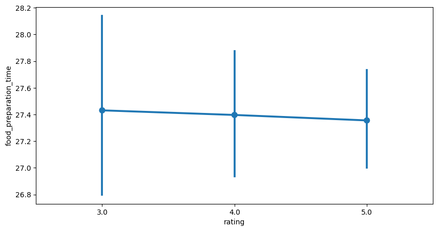

```python
plt.figure(figsize=(10, 5))
sns.pointplot(data=df, x = 'rating', y = 'food_preparation_time')
plt.show()
```

Observations:

- There is no significant relation seen between food preparation time and the rating received based on the plots above.

**Relation between Rating and Cost of the Order**

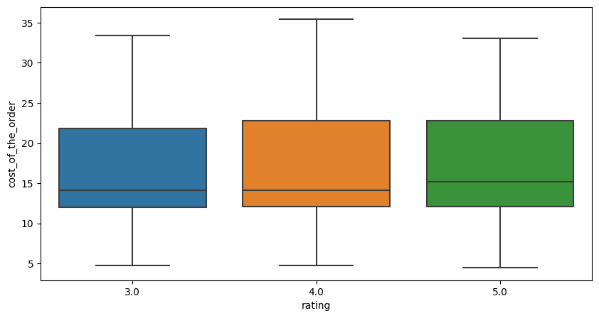

```python
plt.figure(figsize=(10, 5))
sns.boxplot(data=df, x = 'rating', y = 'cost_of_the_order')
plt.show()
```

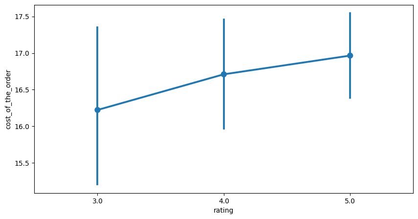

```python
plt.figure(figsize=(10, 5))
sns.pointplot(data=df, x = 'rating', y = 'cost_of_the_order')
plt.show()
```

Observations:

```python
# Lets find the revenue generated by restaurants and list 20 of them in descending order.
df.groupby(['restaurant_name'])['cost_of_the_order'].sum().sort_values(ascending = False).head(20)
```

```
restaurant_name
Shake Shack                             3579.530
The Meatball Shop                       2145.210
Blue Ribbon Sushi                       1903.950
Blue Ribbon Fried Chicken               1662.290
Parm                                    1112.760
RedFarm Broadway                         965.130
RedFarm Hudson                           921.210
TAO                                      834.500
Han Dynasty                              755.290
Blue Ribbon Sushi Bar & Grill            666.620
Rubirosa                                 660.450
Sushi of Gari 46                         640.870
Nobu Next Door                           623.670
Five Guys Burgers and Fries              506.470
Momoya                                   492.130
Chipotle Mexican Grill $1.99 Delivery    491.690
Blue Ribbon Sushi Izakaya                485.090
Tamarind TriBeCa                         426.710
Jack's Wife Freda                        416.750
Bareburger                               399.740
Name: cost_of_the_order, dtype: float64
```

Observations:

- The restaurant Shake Shack has the largest revenue.

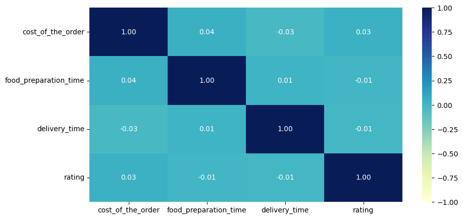

```python
# Plot the heatmap
numerical_variables = ['cost_of_the_order', 'food_preparation_time', 'delivery_time','rating']
plt.figure(figsize=(10, 5))
sns.heatmap(data=df[numerical_variables].corr(), annot=True, vmin=-1, vmax=1,fmt=".2f", cmap="YlGnBu")
plt.show()
```

Observations:

- There is no any strong positive or negative correlation between variables.
- Food preparation time and cost of the order have highest (weak) positive correlation (0.04) as expected.
- Rating and cost of the order also have weak positive correlation (0.03) while delivery time and cost of the order have weak negative correlation (-0.03).

### **Question 13:** The company wants to provide a promotional offer in the advertisement of the restaurants. The condition to get the offer is that the restaurants must have a rating count of more than 50 and the average rating should be greater than 4. Find the restaurants fulfilling the criteria to get the promotional offer. [3 marks]

```python
# Create a dataframe that contain the restaurant names with their rating count
rating_count=df.groupby(['restaurant_name'])['rating'].count().sort_values(ascending=False).reset_index()
# Converte the 'rating' column to numeric
rating_count['rating'] = pd.to_numeric(rating_count['rating'])
# Rename the 'rating' column as Rating _Counts
rating_count.rename(columns={'rating':'Rating_Counts'}, inplace=True)
print(rating_count)
```

```
               restaurant_name  Rating_Counts
0                  Shake Shack            133
1            The Meatball Shop             84
2            Blue Ribbon Sushi             73
3    Blue Ribbon Fried Chicken             64
4             RedFarm Broadway             41
..                         ...            ...
173               Market Table              0
174             Paul & Jimmy's              0
175               Room Service              0
176                  Rohm Thai              0
177              Lamarca Pasta              0

[178 rows x 2 columns]
```

```python
# Create a dataframe that contain the restaurant names and their average rating
average_rating=df.groupby(['restaurant_name'])['rating'].mean().dropna().sort_values(ascending=False).reset_index()
# Rename the 'rating' column as Average_Rating
average_rating.rename(columns={'rating':'Average_Rating'}, inplace=True)
print(average_rating)
```

```
                   restaurant_name  Average_Rating
0                       'wichcraft           5.000
1             Ravagh Persian Grill           5.000
2    Chola Eclectic Indian Cuisine           5.000
3                      Chote Nawab           5.000
4                           Junoon           5.000
..                             ...             ...
151                       Woorijip           3.000
152              Byblos Restaurant           3.000
153                    Pepe Giallo           3.000
154                   Sushi Choshi           3.000
155                Sarabeth's West           3.000

[156 rows x 2 columns]
```

```python
# Merge the dataframes based on a common column 'restaurant_name'
merged_df = pd.merge(rating_count,average_rating, on='restaurant_name')

# Extract data based on conditions
promotional_restaurants = merged_df[(merged_df['Rating_Counts'] > 50) & (merged_df['Average_Rating'] >4)]

# Print the filtered dataframe
print(promotional_restaurants)
```

```
             restaurant_name  Rating_Counts  Average_Rating
0                Shake Shack            133           4.278
1          The Meatball Shop             84           4.512
2          Blue Ribbon Sushi             73           4.219
3  Blue Ribbon Fried Chicken             64           4.328
```

#### Observations:

- There are four restaurants that met the criteria to get the promotional offer.
- Names of these restaurants are Shake Shack, The Meatball Shop, Blue ribbon Sushi and Blue Ribbon Fried Chicken.

### **Question 14:** The company charges the restaurant 25% on the orders having cost greater than 20 dollars and 15% on the orders having cost greater than 5 dollars. Find the net revenue generated by the company across all orders. [3 marks]

```python
# Calculate the revenue for orders with cost greater than $20
revenue_20 = df[df['cost_of_the_order'] > 20]['cost_of_the_order'].sum() * 0.25

# Calculate the revenue for orders with cost greater than $5 (excluding those greater than $20)
revenue_5 = df[(df['cost_of_the_order'] > 5) & (df['cost_of_the_order'] <= 20)]['cost_of_the_order'].sum() * 0.15

# Calculate the total net revenue generated
net_revenue = revenue_20 + revenue_5

# Print the net revenue
print("The net revenue generated by the company is $",round(net_revenue,2))
```

```
The net revenue generated by the company is $ 6166.3
```

#### Observations:

- The net revenue generated by company is $ 6166.3

### **Question 15:** The company wants to analyze the total time required to deliver the food. What percentage of orders take more than 60 minutes to get delivered from the time the order is placed? (The food has to be prepared and then delivered.) [2 marks]

```python
# Assuming your dataframe is named 'df' and contains a column 'delivery_time'
df['total_delivery_time']=df['food_preparation_time'] + df['delivery_time']

# Calculate the percentage of orders that take more than 60 minutes to deliver
percentage = (df[df['total_delivery_time'] > 60]['total_delivery_time'].count() / df['total_delivery_time'].count()) * 100

# Print the percentage
print("The percentage of orders taking more than 60 minutes to deliver is:", round(percentage,2),"%")
```

```
The percentage of orders taking more than 60 minutes to deliver is: 10.54 %
```

#### Observations:

- 10.54 % of the orders take more than 60 minutes to deliver.

### **Question 16:** The company wants to analyze the delivery time of the orders on weekdays and weekends. How does the mean delivery time vary during weekdays and weekends? [2 marks]

```python
# Group the data by day of the week and calculate the mean delivery time
mean_delivery_time=df.groupby(['day_of_the_week'])['delivery_time'].mean().round()
# Print the mean delivery time for weekdays and weekends
print(mean_delivery_time)
```

```
day_of_the_week
Weekday   28.000
Weekend   22.000
Name: delivery_time, dtype: float64
```

#### Observations:

- On average, delivering orders on weekdays take 6 min longer than delivering orders on weekend.
- The average delivery time for orders on the weekday (28 min) is 6 min longer than average delivery time on weekend (22 min).

### Recommendations:

- Enhance Personalized Recommendations: Utilize the available customer data, including past orders and preferences, to develop a recommendation system that suggests relevant restaurants and cuisines to individual customers. This can improve customer experience and increase order frequency.
- Collaborate with Popular Restaurants: Establish strong partnerships with popular restaurants with high order volumes that are 'Shake Shack', 'The Meatball Shop', 'Blue Ribbon Sushi','Bule Ribbon Fried Chicken' and 'Parm' restaurants. This can include negotiating exclusive deals, offering promotions, and ensuring consistent quality of service from these key partners.
- Customer Sentiment Analysis: Analyze customer reviews and feedback. There is a need for more data to gain insights into customer sentiments, identify areas of improvement, and address any recurring issues to enhance overall customer satisfaction.
- Loyalty and Referral Programs: Implement loyalty programs to reward frequent customers and referral programs to incentivize customers to refer others. This can help in customer retention, acquisition, and building a strong customer base.
- Based on the observation that the number of orders given on weekends is significantly higher than the number of orders given on weekdays, I recommend the following actions to leverage this information:

  Resource Allocation and Staffing: Allocate resources and staffing levels accordingly to meet the increased demand during weekends. Ensure sufficient delivery personnel, customer support are available to handle the higher order volumes and deliver excellent service.

  Optimize Delivery Logistics: Analyze and optimize the delivery logistics to handle the peak demand on weekends. Consider implementing route optimization algorithms, real-time tracking systems, and efficient dispatching methods to ensure timely deliveries and enhance customer satisfaction.

  Promotional Campaigns and Offers: Leverage the higher demand on weekends by planning targeted promotional campaigns and offers. Use customer data and analytics to identify customer preferences, popular cuisines, and ordering patterns during weekends. Design attractive offers, discounts, or special menus to incentivize customers to place orders and increase revenue during these peak periods.

  Enhanced Customer Support: Increase customer support availability during weekends to address any queries, concerns, or issues promptly. Ensure customers can easily reach out for assistance through multiple channels such as phone, chat, or email. Quick and efficient resolution of customer inquiries contributes to a positive customer experience.

  Menu Optimization: American cuisine is the most favorite cuisine among the orders given on weekends. Highlight popular dishes, introduce limited-time specials, or collaborate with restaurants to offer exclusive weekend-only items from American cuisine. This can cater to customer preferences and further enhance the weekend ordering experience.

  Customer Communication: Proactively communicate with customers about any operational changes or updates during weekends. Keep customers informed about estimated delivery times, any delays, or promotions happening during peak periods. Transparent and timely communication helps manage customer expectations and maintains a positive brand image.

  Performance Monitoring and Analysis: Continuously monitor and analyze key performance indicators (KPIs) related to weekend orders. Track metrics such as order volume, delivery time, customer feedback, and revenue generated during weekends. This data-driven approach provides insights into the effectiveness of strategies and enables data-backed decision-making for continuous improvement.
- Market Expansion Analysis: Utilize more data to identify potential areas for market expansion. Analyze customer demographics, preferences, and competition in new locations to make informed decisions on entering new markets.